# Hypothetical Example

To demonstrate the utility of the general `categoryCompare` approach, we will construct an artificial data set based on the Gene Ontology. We will attempt to demonstrate that differences in the **set** or **list** based comparisons are also dependent on the number of items annotated to a particular term.

## Definitions

**Set** based: calculations performed independently on each *set* of features, and then the results are combined.

**List** based: calculations performed on the intersected *list* of two sets of features.

## GO Terms

```r
library(ggplot2)
library(ggthemes)
useTheme <- theme_gdocs()
```

We will make use of three sets of GO terms from *H. sapiens*. For each set, we want differing numbers of genes annotated to them.

### Num Annotations Dist

Let's first look at the distribution of number of genes annotated to the GO terms in **biological process**

```r
library(org.Hs.eg.db)
library(GO.db)
library(ccPaperRevHypo)
hsGO <- as.list(org.Hs.egGO2ALLEGS)

goOntology <- Ontology(names(hsGO))
goBP <- names(goOntology)[goOntology == "BP"]
hsGO <- hsGO[goBP]
hsGO <- lapply(hsGO, unique)
universeGenes <- unique(unlist(hsGO))
```

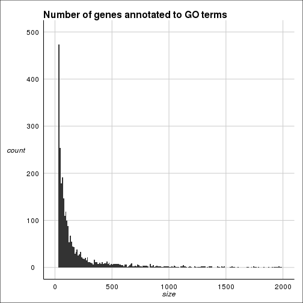

```r
hsGO_count <- sapply(hsGO, length)
hsGO_count <- data.frame(size = hsGO_count)
ggplot(hsGO_count, aes(x = size)) + geom_bar(binwidth = 10) + xlim(0, 2000) +
    ylim(0, 500) + useTheme + ggtitle("Number of genes annotated to GO terms")
```

### Set up groups

Based on the distribution in the previous figure, we will set up 3 different groups of GO terms, with a different number from each group:

- low: 10-100, 50 terms
- med: 250-500, 30 terms
- hi: 500-1500, 20 terms

This gives us a total of 100 GO terms, with a good sample from each group. We will generate random samples that are defined by these limits, and use this set of GO terms going forward.

```r
grpLow <- c(10, 100)
grpMed <- c(250, 500)
grpHi <- c(500, 1500)
```

```r
set.seed(271113)  # for reproducibility
nGO <- c(50, 30, 20)
names(nGO) <- c("low", "med", "hi")

GO_low <- limitedRandomSample(hsGO_count, grpLow, nGO["low"])
GO_med <- limitedRandomSample(hsGO_count, grpMed, nGO["med"])
GO_hi <- limitedRandomSample(hsGO_count, grpHi, nGO["hi"])

useGO <- c(GO_low, GO_med, GO_hi)
useGOSizeClass <- c(rep("low", nGO["low"]), rep("med", nGO["med"]), rep("hi",
    nGO["hi"]))
names(useGOSizeClass) <- useGO
```

### Examine Gene-GO Distribution for Real Data

Before we go and generate our samples, we should actually process some real experimental data and examine the fraction of annotated genes in the experiment compared to the total number of genes annotated. We will use the [`ALL`][http://master.bioconductor.org/packages/release/data/experiment/html/ALL.html] data set from `Bioconductor` and a [paired lung cancer dataset][http://www.ncbi.nlm.nih.gov/geo/query/acc.cgi?acc=GSE18842] available from GEO (available as part of this package).

#### ALL

The `ALL` data set has two classes of tumor, **B** and **T**-cell lymphoblastoma. We will do a simple differential expression between the two cell types.

```r
library(ALL)
library(limma)
data(ALL)

grpALL <- factor(strtrim(pData(ALL)$BT, 1))
designALL <- model.matrix(~0 + grpALL)
colnames(designALL) <- c("B", "T")
fitALL <- lmFit(ALL, designALL)
contMatrixALL <- makeContrasts(BvT = B - T, levels = designALL)
fitALL2 <- contrasts.fit(fitALL, contMatrixALL)
fitALL2 <- eBayes(fitALL2)
deALL <- rownames(topTable(fitALL2, adjust = "BH", p.value = 0.05, number = Inf))
```

Now for all the GO terms that map to the probes in the `ALL` differentially expressed genes, how does the proportion of differentially expressed genes change as a function of the number of genes annotated to the GO term?

```r
library(hgu95av2.db)
```

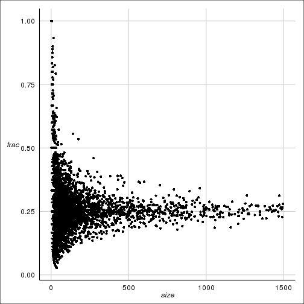

```r
ALLgo <- as.list(hgu95av2GO2ALLPROBES)
ALL_sizeFrac <- trimGOFrac(ALLgo, deALL)
ggplot(ALL_sizeFrac, aes(x = size, y = frac)) + geom_point() + xlim(0, 1500) +
    useTheme
```

#### Lung Cancer

The lung cancer data is a paired sample design from GEO.

```r
data(lung)
sampleStat <- strsplit2(pData(lung)$title, " ")

notNP <- grep("^NP", sampleStat[, 2], invert = T)
lung <- lung[, notNP]
sampleStat <- sampleStat[notNP, ]

sampleID <- factor(sampleStat[, 2])
cancerID <- factor(sampleStat[, 1])

lungDesign <- model.matrix(~sampleID + cancerID)
fitLung <- lmFit(lung, lungDesign)
fitLung <- eBayes(fitLung)
deLung <- rownames(topTable(fitLung, coef = "cancerIDTumor", number = 2000,
    adjust.method = "BY", p.value = 1e-05))
```

```r
library(hgu133plus2.db)
```

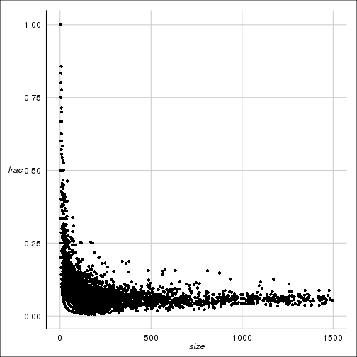

```r
lung2go <- as.list(hgu133plus2GO2ALLPROBES)
lung_sizeFrac <- trimGOFrac(lung2go, deLung)
lung_sizeFrac$genelist <- "lung"
ggplot(lung_sizeFrac, aes(x = size, y = frac)) + geom_point() + xlim(0, 1500) +
    useTheme
```

### Get Genes

Now, for all of these we need to generate **two** samples of genes from them to comprise our **differentially expressed** (DE) sets from the genome, representing two different expression experiments.

How do we select these two sets of genes?

- define the maximum number of diff genes for the set
- Randomly sort the GO terms
- For each GO term in turn (i.e. iterating over the GO terms):
  - take a random fraction of genes for that GO term (sampling from an exponentially decaying distribution of possibilites), adding the requisite number of genes
  - If all the genes for a GO term get taken, remove that GO term from future consideration
- Continue iterating through until the total number of genes is reached

What we expect from this is that in both datasets, the GO terms with lower numbers of genes annotated will have large fractions of their annotations present, while GO terms with more and more genes will have lower fractions, and there will be less overlap between the two datasets.

These expectations should be checked.

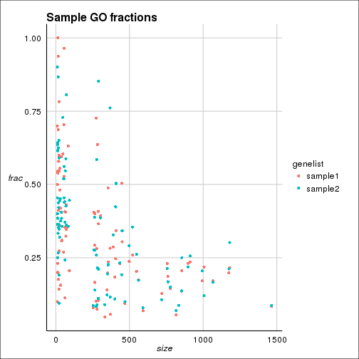

```r
goList <- list(low = GO_low, med = GO_med, hi = GO_hi)
nGene <- 1000
sample1_org <- sampleTerms(useGO, hsGO, 1000, 4)[1:nGene]
sample2_org <- sampleTerms(useGO, hsGO, 1000, 4)[1:nGene]

# check our expectations
goFractions <- calcFraction(hsGO[useGO], list(sample1 = sample1_org, sample2 = sample2_org))
ggplot(goFractions, aes(x = size, y = frac, color = genelist)) + geom_point() +
    useTheme + ggtitle("Sample GO fractions")
```

### Compare to experimental

Lets actually compare this to the distribution of fractions *vs* sizes from the experimental data sets. Because those used **all** the GO terms, we will redo them with **all** GO terms as well, not just those from our sample.

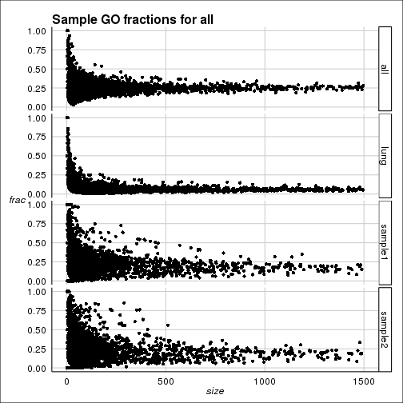

```r
sampleGOFracs <- calcFraction(hsGO, list(sample1 = sample1_org, sample2 = sample2_org))
ALL_sizeFrac$genelist <- "all"
ALL_tmp <- rbind(ALL_sizeFrac, lung_sizeFrac, sampleGOFracs[, c("frac", "genelist",
    "size")])
ggplot(ALL_tmp, aes(x = size, y = frac)) + geom_point() + xlim(0, 1500) + facet_grid(genelist ~
    .) + useTheme + ggtitle("Sample GO fractions for all")
```

```r
keepItems <- c("goFractions", "sample1_org", "sample2_org", "hsGO", "useGO",
    "useGOSizeClass", "GO_hi", "GO_low", "GO_med", "grpHi", "grpLow", "grpMed",
    "minGO", "nGO", "nGene", "universeGenes")
allItems <- ls()
delItems <- allItems[!(allItems %in% keepItems)]
rm(list = delItems)
```

### Do calculations

For each `geneList`, we will do the GO enrichment calculations, and then get the results. We also do the intersection of all the `geneList`'s, and do the calculations again.

```r
samples_noNoise <- list(sample1 = sample1_org, sample2 = sample2_org)
go_noNoise <- hyperGOMultiEnrichment(samples_noNoise, universe = universeGenes)
```

Now get the p-values out (`-1 * log10(pvalue)`). For each of our test GO terms, we take the minimum p-value from the results of the **set** calculations, and also the values from the **list** calculations.

```r
noNoise_results <- pvaluesMultiEnrich(c("sample1", "sample2"), useGO, go_noNoise)

noNoise_pvalues <- pvalueDiffSig(noNoise_results$values, pCutoff = 0.05, log = TRUE)
```

Finally, lets add in our values of the fraction, total genes, and the class (**low**, **med**, **hi**) so we can do some fancy plotting stuff with it.

```r
noNoise_pvalues$sizeClass <- useGOSizeClass
noNoise_pvalues$size <- goFractions[1:length(useGOSizeClass), 4]
noNoise_pvalues$frac <- goFractions$frac[1:length(useGOSizeClass)]
```

Now we will plot the difference in log-p-values (where we have **set** - **list**), so that positive values imply that **set** had lower p-values than **list**, based on the *fraction* of genes annotated.

```r
noNoise_pvalues$sizeClass <- factor(noNoise_pvalues$sizeClass, levels = c("low",
    "med", "hi"), ordered = TRUE)
ggplot(noNoise_pvalues, aes(x = frac, y = diff, color = sigState)) + geom_point() +
    facet_grid(. ~ sizeClass, scales = "free_x") + xlab("fraction") + useTheme +
    ggtitle("Sample - Combined Differences")
```

```
## Error: object 'useTheme' not found
```

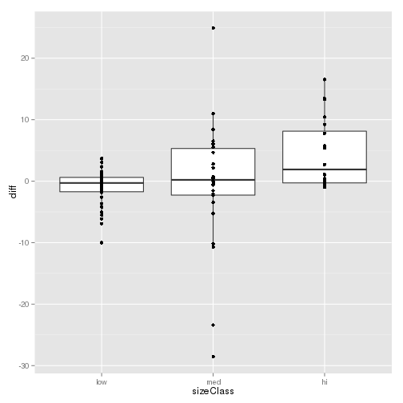

```r
ggplot(noNoise_pvalues, aes(x = sizeClass, y = diff)) + geom_boxplot() + geom_point()
```

How many of the GO terms have better p-values in **set** compared to **list**?

```r
tapply(noNoise_pvalues$diff, noNoise_pvalues$sizeClass, function(x) {
    sum(x > 0)
})
```

```
## low med  hi
##  23  16  14
```

What is the average difference among each group?

```r
tapply(noNoise_pvalues$diff, noNoise_pvalues$sizeClass, mean)
```

```
##     low     med      hi
## -0.8243 -0.1824  4.4454
```

So ideally, the mean of the full set of differences, combined with how many pass in each case, should adequately quantify how well each of the methods is doing.

## Noise

In addition to the genes that are annotated to the GO terms of interest, we will also add in genes that have no relation to the GO terms under consideration, these would be considered **noise** genes. To make the model simple, we will have the **same** genes as noise in **both** samples.

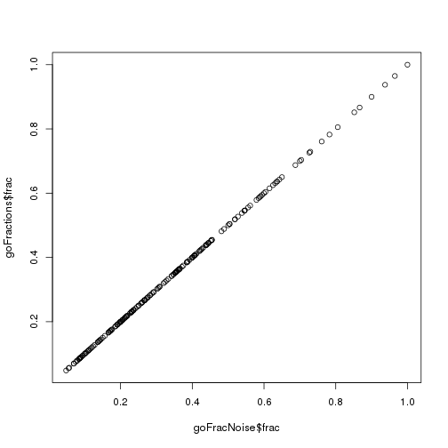

```r
nNoise <- 500
noiseGenes <- possibleNoise(hsGO, useGO)
noiseGenes <- sample(noiseGenes, nNoise)

# check that we did this right, the fraction should not change after adding
# noise genes
sample1 <- c(sample1_org, noiseGenes)
sample2 <- c(sample2_org, noiseGenes)

samplesNoise <- list(sample1 = sample1, sample2 = sample2)

goFracNoise <- calcFraction(hsGO[useGO], samplesNoise)
plot(goFracNoise$frac, goFractions$frac)
```

```r
go_noise <- hyperGOMultiEnrichment(samplesNoise, universeGenes)
```

```r
noise_results <- pvaluesMultiEnrich(c("sample1", "sample2"), useGO, go_noise)

noise_pvalues <- pvalueDiffSig(noise_results$values, pCutoff = 0.05, log = TRUE)

noise_pvalues$sizeClass <- useGOSizeClass
noise_pvalues$size <- goFracNoise[1:length(useGOSizeClass), 4]
noise_pvalues$frac <- goFracNoise$frac[1:length(useGOSizeClass)]
```

```r
noise_pvalues$sizeClass <- factor(noise_pvalues$sizeClass, c("low", "med", "hi"),
    ordered = TRUE)
ggplot(noise_pvalues, aes(x = frac, y = diff, color = sigState)) + geom_point() +
    facet_grid(. ~ sizeClass, scales = "free_x") + useTheme + ggtitle("Sample - Combined with Noise")
```

```
## Error: object 'useTheme' not found
```

```r
tapply(noise_pvalues$diff, noise_pvalues$sizeClass, function(x) {
    sum(x > 0)
})
```

```
## low med  hi
##  32  24  18
```

```r
tapply(noise_pvalues$diff, noise_pvalues$sizeClass, mean)
```

```
##    low    med     hi
## 0.4028 4.0175 7.3028
```

### Difference of Differences

Is there any **difference** in the *difference of p-values* between **noise** vs **noNoise** (comparing **set** vs **list**)?

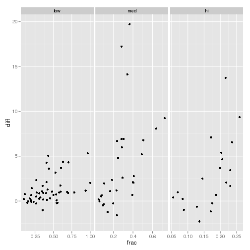

```r
diff_pvalues <- noise_pvalues
diff_pvalues$diff <- noise_pvalues$diff - noNoise_pvalues$diff
ggplot(diff_pvalues, aes(x = frac, y = diff)) + geom_point() + facet_grid(. ~
    sizeClass, scales = "free_x")
```

```r
tapply(diff_pvalues$diff, diff_pvalues$sizeClass, mean)
```

```
##   low   med    hi
## 1.227 4.200 2.857
```

From this plot, it appears that not only do the **set** values return lower p-values, but return lower p-values when noise is added overall.

## Check Consistency

To make sure that the results are consistent, we will do several iterations of the above calculations.

- For this set of GO terms, do the above calculations 100 times
- Generate 100 different sets of GO terms, and run calculations again.

### Gene Sample Level Consistency

```r
nTimes <- 100
nGene <- 1000

testSamples <- lapply(seq(1, nTimes), function(x) {
    list(s1 = sampleTerms(useGO, hsGO, 1000, 4)[1:nGene], s2 = sampleTerms(useGO,
        hsGO, 1000, 4)[1:nGene], noise = sample(noiseGenes, nNoise))
})

save(useGO, testSamples, universeGenes, useGOSizeClass, file = "inst/data/100GeneSamples.RData")
```

```r
data(100GeneSamples)
library(snowfall)
# load("inst/data/100GeneSamples.RData")
testFun <- function(x){
  nnList <- x[c("s1", "s2")]
  nnRes <- hyperGOMultiEnrichment(nnList, universe=universeGenes)
  nn_res <- pvaluesMultiEnrich(c("s1", "s2"), useGO, nnRes)
  nnP <- pvalueDiffSig(nn_res$values, pCutoff=0.05, log=TRUE)
  nnP$class <- useGOSizeClass

  noiList <- list(s1 = c(x$s1, x$noise), s2 = c(x$s2, x$noise))
  noiRes <- hyperGOMultiEnrichment(noiList, universe=universeGenes)
  noi_res <- pvaluesMultiEnrich(c("s1", "s2"), useGO, noiRes)
  noiP <- pvalueDiffSig(noi_res$values, pCutoff=0.05, log=TRUE)
  noiP$class <- useGOSizeClass

  return(list(clean = nnP, noise = noiP))
}
sfInit(parallel=TRUE, cpus=10)
sfExport("useGOSizeClass", "universeGenes", "useGO")
sfLibrary(ccPaperRev)
sfLibrary(GO.db)
sfLibrary(org.Hs.eg.db)
testRes <- sfLapply(testSamples, testFun)
sfStop()
save(testRes, file="inst/data/100GeneResults.RData")
```

### Errors from 100 Samples of the initial set of GO terms

For each of the GO terms, we want to calculate the mean, standard deviation, and then a 95% confidence interval to represent graphically.

```r
data("100GeneResults")
cleanRes <- lapply(testRes, function(x) {
    x$clean
})
testStats_clean <- sameGOStats(cleanRes)
testStats_clean$class <- useGOSizeClass
testStats_clean$frac <- goFractions$frac[1:length(useGOSizeClass)]
testStats_clean$class <- factor(testStats_clean$class, levels = c("low", "med",
    "hi"), ordered = TRUE)
ggplot(testStats_clean, aes(x = frac, y = mean, ymax = max, ymin = min)) + geom_point() +
    geom_errorbar() + facet_grid(. ~ class, scales = "free_x") + useTheme
```

```
## Error: object 'useTheme' not found
```

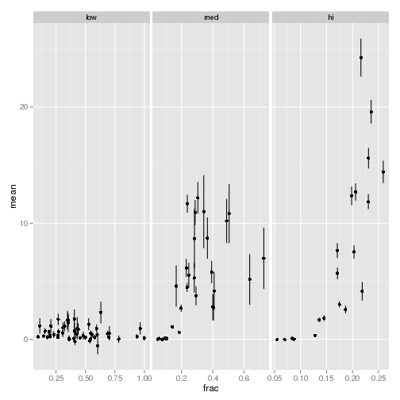

```r
noiseRes <- lapply(testRes, function(x) {
    x$noise
})
testStats_noise <- sameGOStats(noiseRes)
testStats_noise$class <- useGOSizeClass
testStats_noise$frac <- goFracNoise$frac[1:length(useGOSizeClass)]
testStats_noise$class <- factor(testStats_noise$class, levels = c("low", "med",
    "hi"), ordered = TRUE)
ggplot(testStats_noise, aes(x = frac, y = mean, ymax = max, ymin = min)) + geom_point() +
    geom_errorbar() + facet_grid(. ~ class, scales = "free_x")
```

These show that if there is a difference in the p-values from **set** and **list**, they are real.

What about differences between noise and clean?

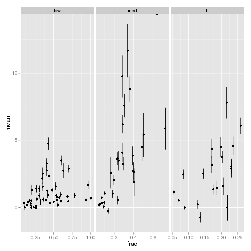

```r
noiseCleanDiff <- diffGOStats(testRes)
noiseCleanDiff$class <- useGOSizeClass
noiseCleanDiff$frac <- goFracNoise$frac[1:length(useGOSizeClass)]
noiseCleanDiff$class <- factor(noiseCleanDiff$class, levels = c("low", "med",
    "hi"), ordered = TRUE)
ggplot(noiseCleanDiff, aes(x = frac, y = mean, ymax = max, ymin = min)) + geom_point() +
    geom_errorbar() + facet_grid(. ~ class, scales = "free_x")
```

Here we see that the noisy case also tends to generate higher differences in p-values between **set** and **list** than the clean case.

**Caveats**: Currently the *fraction* of genes annotated to GO terms is assumed to be the same for each sample. This may not actually be the case, and ideally this should be repeated with independent fraction estimates for each sampling.

## GO Samples

OK, the error bars are not too bad. How about sampling multiple sets of GO terms??

```r
goLimits <- list(low = c(10, 100), med = c(250, 500), hi = c(500, 1500))

nSample <- 100

sfInit(parallel = TRUE, cpus = 10)
sfLibrary(ccPaperRev)
sfExport("hsGO", "nGO", "goLimits")

testGOSample <- sfLapply(seq(1, nSample), function(x) {
    t1 <- goSample(hsGO, nGO, goLimits, nSample = 2, nGene = 1000, nNoise = 500)
    return(t1)
})

sfStop()
save(testGOSample, file = "inst/data/100GOSamples.RData")
```

Running those samples:

```r
data("100GOSamples")
runGOSamples <- function(x) {
    cleanSample <- x$geneSample
    cleanRes <- hyperGOMultiEnrichment(cleanSample, universe = universeGenes)

    cleanP <- pvaluesMultiEnrich(names(cleanSample), x$goData$id, cleanRes)
    cleanP_dif <- pvalueDiffSig(cleanP$values, pCutoff = 0.05, log = TRUE)
    cleanP_dif <- cbind(cleanP_dif, x$goData)

    noiseSample <- lapply(names(cleanSample), function(inSample) {
        c(x$geneSample[[inSample]], x$noiseSample[[inSample]])
    })
    names(noiseSample) <- names(cleanSample)
    noiseRes <- hyperGOMultiEnrichment(noiseSample, universe = universeGenes)
    noiseP <- pvaluesMultiEnrich(names(cleanSample), x$goData$id, noiseRes)
    noiseP_dif <- pvalueDiffSig(noiseP$values, pCutoff = 0.05, log = TRUE)
    noiseP_dif <- cbind(noiseP_dif, x$goData)
    return(list(clean = cleanP_dif, noise = noiseP_dif))
}

library(snowfall)
sfInit(parallel = TRUE, cpus = 10)
sfLibrary(ccPaperRev)
sfLibrary(org.Hs.eg.db)
sfLibrary(GO.db)
sfExport("universeGenes")

testGORes <- sfLapply(testGOSample, runGOSamples)
sfStop()
save(testGORes, file = "inst/data/100GOResults.RData")
```

```r
data("100GOResults")

grab_noNoise <- function(x) {
    x$clean[, c("diff", "class", "frac")]
}

go_noNoise <- lapply(testGORes, grab_noNoise)
go_noNoise <- do.call(rbind, go_noNoise)
go_noNoise$class <- factor(go_noNoise$class, levels = c("low", "med", "hi"),
    ordered = TRUE)
go_noNoiseT <- go_noNoise[(!is.nan(go_noNoise$diff)), ]
ggplot(go_noNoiseT, aes(x = frac, y = diff)) + geom_point() + facet_grid(. ~
    class, scales = "free_x") + useTheme + stat_density2d(aes(fill = ..level..),
    geom = "polygon")
```

```
## Error: object 'useTheme' not found
```

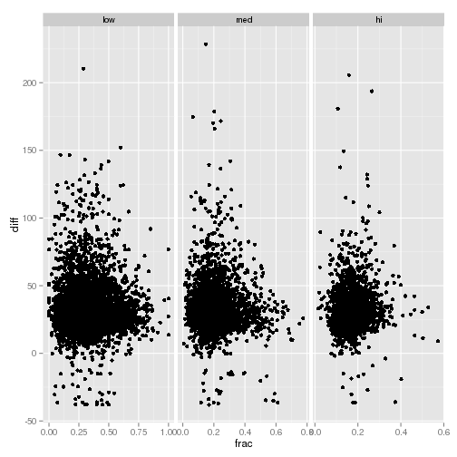

```r
grab_noise <- function(x) {
    x$noise[, c("diff", "class", "frac")]
}
go_noise <- lapply(testGORes, grab_noise)
go_noise <- do.call(rbind, go_noise)
go_noise$class <- factor(go_noise$class, levels = c("low", "med", "hi"), ordered = TRUE)
ggplot(go_noise, aes(x = frac, y = diff)) + geom_point() + facet_grid(. ~ class,
    scales = "free_x")
```

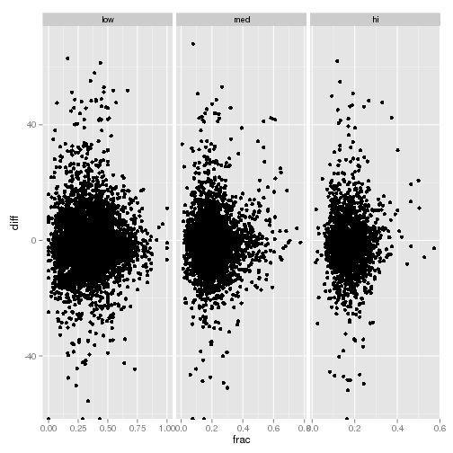

```r
grab_noiseDiff <- function(x) {
    outRes <- x$clean[, c("diff", "class", "frac")]
    outRes$diff <- x$noise$diff - x$clean$diff
    outRes
}
go_diff <- lapply(testGORes, grab_noiseDiff)
go_diff <- do.call(rbind, go_diff)
go_diff$class <- factor(go_diff$class, levels = c("low", "med", "hi"), ordered = TRUE)
ggplot(go_diff, aes(x = frac, y = diff)) + geom_point() + facet_grid(. ~ class,
    scales = "free_x")
```

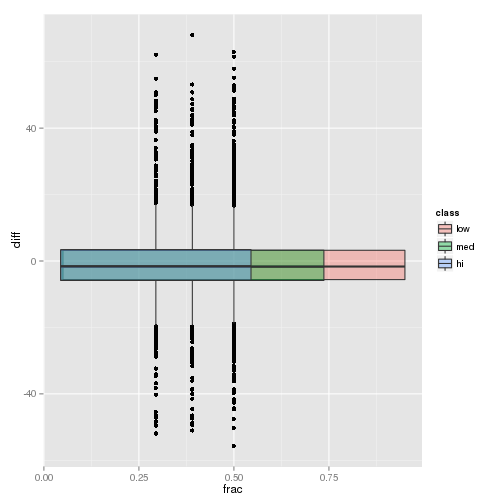

```r
ggplot(go_diff, aes(x = frac, y = diff, fill = class)) + geom_boxplot(position = "identity",
    alpha = 0.4)
```

How about we compare the distribution of noise and no-noise using violin plots?

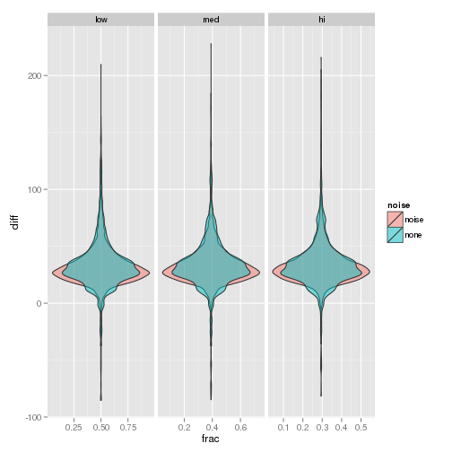

```r
go_noise$noise <- "noise"
go_noNoise$noise <- "none"

go_all <- rbind(go_noise, go_noNoise)
rownames(go_all) <- NULL
ggplot(go_all, aes(x = frac, y = diff, fill = noise)) + geom_violin(trim = TRUE,
    alpha = 0.5, position = "identity") + facet_grid(. ~ class, scales = "free_x")
```

What if we aggregate things into bins first, based on their class and fraction?

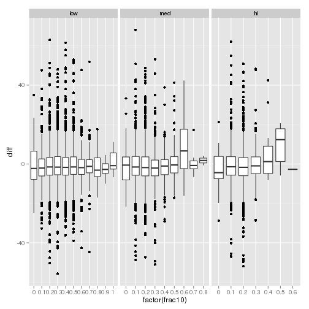

```r
go_diff$frac10 <- round(go_diff$frac * 10)/10
ggplot(go_diff, aes(x = factor(frac10), y = diff)) + geom_boxplot() + facet_grid(. ~
    class, scales = "free_x")
```

```
## geom_smooth: method="auto" and size of largest group is >=1000, so using gam with formula: y ~ s(x, bs = "cs"). Use 'method = x' to change the smoothing method.
## geom_smooth: method="auto" and size of largest group is >=1000, so using gam with formula: y ~ s(x, bs = "cs"). Use 'method = x' to change the smoothing method.
## geom_smooth: method="auto" and size of largest group is >=1000, so using gam with formula: y ~ s(x, bs = "cs"). Use 'method = x' to change the smoothing method.
```

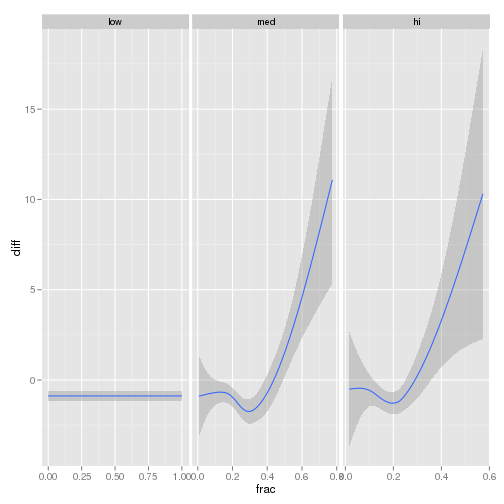

```r
probPoint <- is.infinite(go_diff$diff) | is.na(go_diff$diff) | is.nan(go_diff$diff)
go_diff <- go_diff[!probPoint, ]
ggplot(go_diff, aes(x = frac, y = diff)) + stat_smooth() + facet_grid(. ~ class,
    scales = "free_x")
```

Although the improvement of noise over clean data dips below 0 at medium fractions, it does tend to improve rather significantly as the fraction of genes annotated to a GO term increases.

## As a function of noisy and shared noise genes

For a given set of genes and GO terms, lets now keep adding more and more noise genes, and for the set amount of noise genes, go from 0% to 100% shared noise genes. And then see how things change. For this, we are going to use our initial set of GO terms (`useGO`), and a single original set of genes, simply sampling noise genes as we go along. Note that in this case **noise** genes are defined as genes that are not annotated to any of the GO terms that the DE genes are annotated to.

As in the previous examples, we will generate the samples first, and then run the calculations on them. This is because it is easier to test sample generation and enrichment separately.

```r
noiseGenes <- possibleNoise(hsGO, useGO)
sizeNoise <- seq(0, 1000, 10)
fracShared <- seq(0, 1, 0.01)
noiseSamples <- sweepNoiseSample(noiseGenes, nSamples = 2, sizeNoise, fracShared)

nGene <- 1000
cleanSample <- list(s1 = sampleTerms(useGO, hsGO, nGene, 4)[1:nGene], s2 = sampleTerms(useGO,
    hsGO, nGene, 4)[1:nGene])

save(noiseSamples, cleanSample, sizeNoise, fracShared, universeGenes, useGO,
    useGOSizeClass, file = file.path(useDir, "inst/data/noiseSamples.RData"))
```

```
## Error: object 'useDir' not found
```

```r
data(noiseSamples)

useNoise <- unlist(noiseSamples, recursive = FALSE)
sizeNoiseAll <- rep(sizeNoise, each = length(fracShared))
fracSharedAll <- rep(fracShared, length(sizeNoise))

runSweepNoise <- function(noiseGenes) {
    inNoise <- lapply(seq(1, length(cleanSample)), function(x) {
        c(cleanSample[[x]], noiseGenes[[x]])
    })
    names(inNoise) <- names(cleanSample)

    noiseRes <- hyperGOMultiEnrichment(inNoise, universe = universeGenes)
    noiseP <- pvaluesMultiEnrich(names(inNoise), useGO, noiseRes)
    noisePComp <- pvalueDiffSig(noiseP$values, pCutoff = 0.05, log = TRUE)
    noisePComp$class <- useGOSizeClass
    return(noisePComp)
}

library(snowfall)
sfInit(parallel = TRUE, cpus = 10)
sfLibrary(ccPaperRev)
sfLibrary(org.Hs.eg.db)
sfLibrary(GO.db)
sfExport("universeGenes", "useGO", "useGOSizeClass", "cleanSample")
noiseSweepRes <- sfLapply(useNoise, runSweepNoise)
sfStop()
save(noiseSweepRes, file.path(useDir, "inst/data/noiseSweepRes.RData"))
```

Examine the noise results.

```r
data(noiseSamples)
data(noiseSweepRes)
noiseFrac <- data.frame(size = rep(sizeNoise, each = length(fracShared)), shared = rep(fracShared,
    length(sizeNoise)))
```

```r
outMedians <- lapply(noiseSweepRes, function(inRes) {
    tapply(inRes$diff, inRes$class, median)
})
```

```
## Error: error in evaluating the argument 'X' in selecting a method for function 'lapply': Error: object 'noiseSweepRes' not found
```

```r
outMedians <- do.call(rbind, outMedians)
```

```
## Error: object 'outMedians' not found
```

```r
outMedians <- cbind(outMedians, noiseFrac)
```

```
## Error: object 'outMedians' not found
```

```r
ggplot(outMedians, aes(x = size, y = hi, color = shared)) + geom_point() + useTheme +
    ggtitle("Hi Median Difference")
```

```
## Error: object 'outMedians' not found
```

```r
ggplot(outMedians, aes(x = size, y = med, color = shared)) + geom_point() +
    useTheme + ggtitle("Medium Median Difference")
```

```
## Error: object 'outMedians' not found
```

```r
ggplot(outMedians, aes(x = size, y = low, color = shared)) + geom_point() +
    useTheme + ggtitle("Low Median Difference")
```

```
## Error: object 'outMedians' not found
```

```r
outMedians2 <- data.frame(diff = c(outMedians$low, outMedians$med, outMedians$hi),
    class = c(rep("low", nrow(outMedians)), rep("med", nrow(outMedians)), rep("hi",
        nrow(outMedians))), size = rep(outMedians$size, 3), shared = rep(outMedians$shared,
        3))
```

```
## Error: object 'outMedians' not found
```

```r
outMedians2$class <- factor(outMedians2$class, c("low", "med", "hi"), ordered = TRUE)
```

```
## Error: object 'outMedians2' not found
```

```r
ggplot(outMedians2, aes(x = size, y = diff, color = shared)) + geom_point() +
    useTheme + facet_grid(class ~ ., scales = "free_y") + ggtitle("Sample - Combined as a function of size and shared fraction")
```

```
## Error: object 'outMedians2' not found
```

# GSEA

Another way to do the analysis is using a Gene Set Enrichment Analysis, or GSEA. In contrast to over-representation analysis, where we count if a group is more highly represented in a group *vs* the background; GSEA tests if a **set** of genes are more highly ranked than random sets of genes.

For a hypothetical example, we are going to use the `geneSetTest` from `limma`, because it allows us to test on a set of gene statistics themselves.

## Data set up

The sets will be our same GO terms, and we will change the proportion of genes from each GO term that are enhanced above a base value. All genes will be assigned a value from a uniform distribution with a value of 0.5. For each GO term set, some genes will be selected (with an exponential decaying probability for more genes), and assigned p-values from a uniform distribution with a value of 0.01.

For the **list** version, the p-values of genes will be combined using **Fishers** method, see the function `fishersMethod` provided in this package.

## Generate Data

We will use the t-values that `limma` has generated for the ALL data set, and just sample from those.

```r
tALL <- topTable(fitALL2, number = Inf)
```

```
## Error: object 'fitALL2' not found
```

```r
tALL <- tALL$t[(tALL$t < 10) & (tALL$t > -10)]
```

```
## Error: object 'tALL' not found
```

```r
tValues <- runif(length(universeGenes), -6, 6)

gseaSamples <- list(s1 = sampleTerms(useGO, hsGO, 1000, 4), s2 = sampleTerms(useGO,
    hsGO, 1000, 4))

gseaGOFracS1 <- calcFraction(hsGO[useGO], list(s1 = gseaSamples[[1]]))

gseaTValues <- sampletValueGenGSEA(gseaSamples, universeGenes, tValues)
```

Check that we did what we thought. If done right, all of the **sample** genes should be on one side of the a histogram.

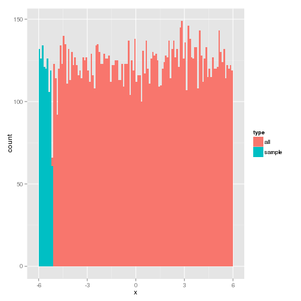

```r
tmpDat <- data.frame(x = gseaTValues[[1]], type = "all", stringsAsFactors = FALSE)
tmpDat$type[(universeGenes %in% gseaSamples[[1]])] <- "sample"
ggplot(tmpDat, aes(x = x, fill = type)) + geom_histogram(binwidth = 0.1, position = "identity")
```

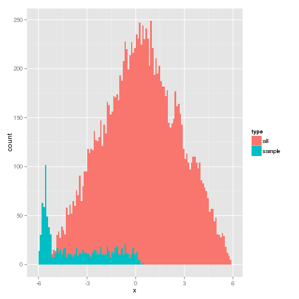

```r
tmpComb <- data.frame(x = gseaTValues[["comb"]], type = "all", stringsAsFactors = FALSE)
tmpComb$type[(universeGenes %in% gseaSamples[[1]])] <- "sample"
ggplot(tmpComb, aes(x = x, fill = type)) + geom_histogram(binwidth = 0.1, position = "identity")
```

Now lets actually do some calculations.

```r
go2index <- symbols2indices(hsGO[useGO], universeGenes)
gseaSetResults <- lapply(gseaTValues, function(x) {
    mmGeneSetTest(go2index, x)
})
```

And figure out what is doing better.

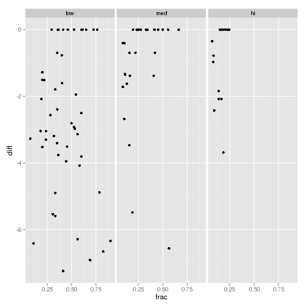

```r
cleanDiff <- gseaDiffs(gseaSetResults)
cleanDiff$sizeClass <- useGOSizeClass
cleanDiff$sizeClass <- factor(cleanDiff$sizeClass, c("low", "med", "hi"), ordered = TRUE)
cleanDiff$frac <- gseaGOFracS1$frac

ggplot(cleanDiff, aes(x = frac, y = diff)) + geom_point() + facet_grid(. ~ sizeClass)
```

So this appears to be a different trend than for the hypergeometric case, in that a **meta** sample (achieved by averaging the t-statistics) actually does no worse, and in many cases much better than the worst p-value. This effect is less-pronounced as the number of genes in a class become larger, and as the fraction covered increases.

So what happens if we add some noisy genes into the top 1000? Stuff that isn't annotated at all to the GO terms of interest?

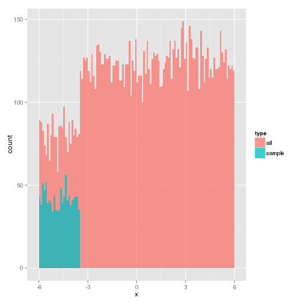

```r
nNoise <- 2000
noiseGenes <- possibleNoise(hsGO, useGO)
noiseGenes <- sample(noiseGenes, nNoise)

gseaNoise <- list(s1 = c(gseaSamples[["s1"]], noiseGenes), s2 = c(gseaSamples[["s2"]],
    noiseGenes))

gseaTValues_noise <- sampletValueGenGSEA(gseaNoise, universeGenes, tValues)

tmpDat <- data.frame(x = gseaTValues_noise[[1]], type = "all", stringsAsFactors = FALSE)
tmpDat$type[(universeGenes %in% gseaSamples[[1]])] <- "sample"
ggplot(tmpDat, aes(x = x, fill = type)) + geom_histogram(binwidth = 0.1, position = "identity",
    alpha = 0.75)
```

```r
gseaSetResults_noise <- lapply(gseaTValues_noise, function(x) {
    mmGeneSetTest(go2index, x)
})
```

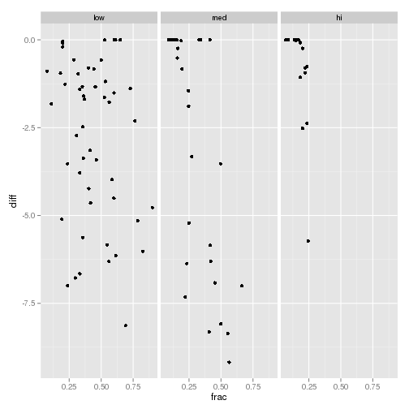

```r
noiseDiff <- gseaDiffs(gseaSetResults_noise)
noiseDiff$sizeClass <- useGOSizeClass
noiseDiff$sizeClass <- factor(noiseDiff$sizeClass, c("low", "med", "hi"), ordered = TRUE)
noiseDiff$frac <- gseaGOFracS1$frac

ggplot(noiseDiff, aes(x = frac, y = diff)) + geom_point() + facet_grid(. ~ sizeClass)
```

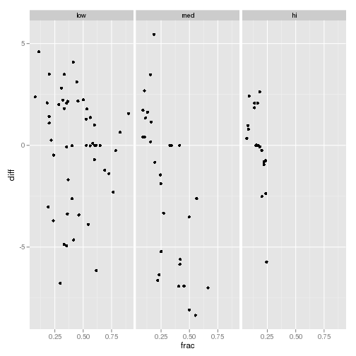

```r
diffDiff <- data.frame(diff = (noiseDiff$diff - cleanDiff$diff), sizeClass = noiseDiff$sizeClass,
    frac = noiseDiff$frac)
ggplot(diffDiff, aes(x = frac, y = diff)) + geom_point() + facet_grid(. ~ sizeClass)
```

So, it appears that having a uniform distribution does not make things behave the way we might expect. What if it is more an issue of independence, that GO is a bad fit for GSEA type analysis because of the issue that many of the terms are heavily overlapped.

### Independence

What if we force independence on our objects? i.e. each object has independent sets of genes, and treat them appropriately? i.e. to count as “diff” we will put genes (features) into the top 50% of ranked t-values (therefore reducing coverage means pushing annotated genes down into the bottom 50% of ranked values), and adding noise means to push un-annotated (i.e. random) above in rank.

Lets try this for a single example.

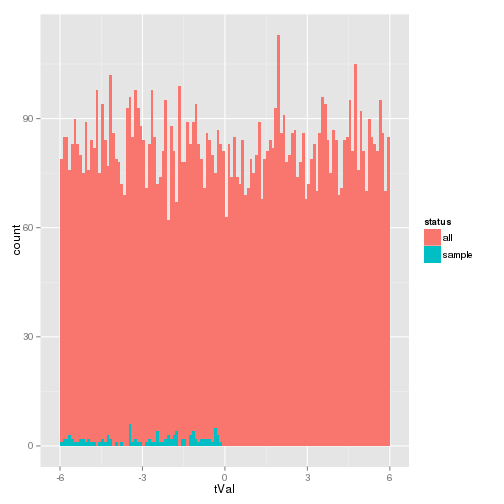

```r
nGene <- 10000
indepTValues <- sort(runif(nGene, -6, 6))
names(indepTValues) <- as.character(seq(1, nGene))

gseaMap <- list(t1 = sample(seq(1, nGene/2), 100))

tmpDat <- data.frame(tVal = indepTValues, status = "all", stringsAsFactors = F)
tmpDat$status[gseaMap[["t1"]]] <- "sample"
ggplot(tmpDat, aes(x = tVal, fill = status)) + geom_histogram(binwidt = 0.1,
    position = "identity")
```

```r
geneSetTest(gseaMap$t1, indepTValues, alternative = "down", ranks.only = FALSE)
```

```
## [1] 1e-04
```

```r
gseaMap80 <- list(t1 = c(sample(seq(1, nGene/2), 80), sample(seq((nGene/2) +
    1, nGene), 20)))

geneSetTest(gseaMap80$t1, indepTValues, alternative = "down", ranks.only = FALSE)
```

```
## [1] 1e-04
```

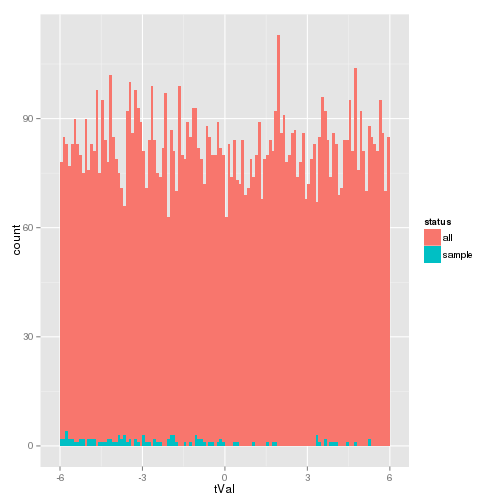

```r
tmpDat <- data.frame(tVal = indepTValues, status = "all", stringsAsFactors = F)
tmpDat$status[gseaMap80[["t1"]]] <- "sample"
ggplot(tmpDat, aes(x = tVal, fill = status)) + geom_histogram(binwidt = 0.1,
    position = "identity")
```

```r
gseaMap50 <- list(t1 = c(sample(seq(1, nGene/2), 50), sample(seq((nGene/2) +
    1, nGene), 50)))

geneSetTest(gseaMap50$t1, indepTValues, alternative = "down", ranks.only = FALSE)
```

```
## [1] 0.4753
```

```r
gseaMapUnif <- list(t1 = sample(nGene, 100))
geneSetTest(gseaMapUnif$t1, indepTValues, alternative = "down", ranks.only = FALSE)
```

```
## [1] 0.148
```

```r
gseaAbove100 <- list(t1 = sample(seq(100, nGene/2), 100))
geneSetTest(gseaAbove100$t1, indepTValues, alternative = "down", ranks.only = FALSE)
```

```
## [1] 1e-04
```

```r
gseaAbove500 <- list(t1 = sample(seq(501, nGene/2), 100))
geneSetTest(gseaAbove500$t1, indepTValues, alternative = "down", ranks.only = FALSE)
```

```
## [1] 1e-04
```

```r
gseaAbove1000 <- list(t1 = sample(seq(1001, nGene/2), 100))
geneSetTest(gseaAbove1000$t1, indepTValues, alternative = "down", ranks.only = FALSE)
```

```
## [1] 1e-04
```

```r
gseaAbove2000 <- list(t1 = sample(seq(2001, nGene/2), 100))
geneSetTest(gseaAbove2000$t1, indepTValues, alternative = "down", ranks.only = FALSE)
```

```
## [1] 1e-04
```

```r
gseaAbove4000 <- list(t1 = sample(seq(4001, nGene/2), 100))
geneSetTest(gseaAbove4000$t1, indepTValues, alternative = "down", ranks.only = FALSE)
```

```
## [1] 0.0275
```

OK, so it takes a rather large proportion above to change the p-value any amount.

So, what should we do. We need a function that will let us vary the size and proportion of genes that are in the bottom 50% of values.

```r
`?`(gseaSizeRange)
`?`(gseaProportion)
```

Lets verify this function is doing what we think it is.

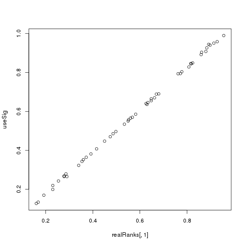

```r
testSize <- gseaSizeRange(c(500, 500), 50)
useStatistics <- runif(10000, -6, 6)
useSig <- runif(50, 0.1, 1)
testStats <- gseaProportion(testSize, useSig, useStatistics)

fullIndex <- seq(1, length(useStatistics))
useCut <- 5000

realRanks <- lapply(testStats, function(inStat) {

    apply(inStat$stats, 2, function(inCol) {
        outRank <- rank(inCol)[inStat$index]
        sum(outRank < useCut)/length(inStat$index)
    })

})

realRanks <- do.call(rbind, realRanks)
plot(realRanks[, 1], useSig)
```

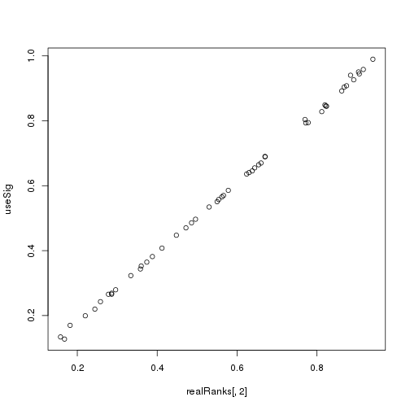

```r
plot(realRanks[, 2], useSig)
```

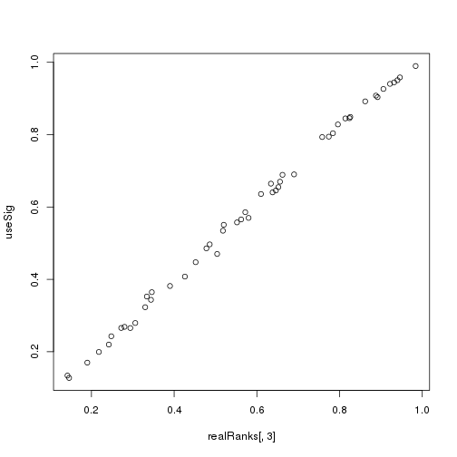

```r
plot(realRanks[, 3], useSig)
```

OK, it looks like it is working. That's good.

```r
testSize <- gseaSizeRange(c(500, 500), 50)
useStatistics <- runif(10000, -6, 6)
useSig <- runif(50, 0.1, 1)
testStats <- gseaProportion(testSize, useSig, useStatistics)

outP <- lapply(testStats, function(inStat) {
    tmpP <- lapply(seq(1, ncol(inStat$stats)), function(useColumn) {
        geneSetTest(inStat$index, inStat$stats[, useColumn], "down", ranks.only = FALSE)
    })
    tmpP <- do.call(cbind, tmpP)
    colnames(tmpP) <- colnames(inStat$stats)
    return(tmpP)
})

outP2 <- do.call(rbind, outP)
outP2 <- -1 * log(outP2)

tmpP <- data.frame(set = apply(outP2[, c("s1", "s2")], 1, min), list = outP2[,
    "comb"])
tmpP$diff <- tmpP$set - tmpP$list
tmpP$frac <- useSig
ggplot(tmpP, aes(x = frac, y = diff)) + geom_point() + useTheme + ggtitle("Sample - Combined average t-statistics")
```

```
## Error: object 'useTheme' not found
```

Yeah, that doesn't seem to really work.

What if GSEA is dependent on the **shared** proportion that is in the up or down state? i.e. if we allow the proportion “down” to vary between the two samples, and plot the difference in **set** and **list** values based on how **close** the value of the proportion in the top is??

```r
`?`(gseaProportionVary)
```

Check that we generate different significant proportions for independent samples, and what is the combined.

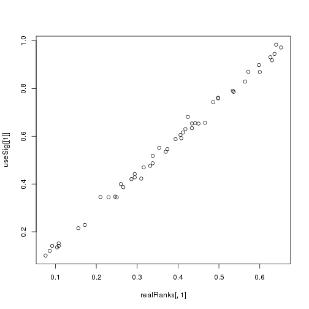

```r
testSize <- gseaSizeRange(c(500, 500), 50)
useStatistics <- runif(10000, -6, 6)
useSig <- list(s1 = runif(50, 0.1, 1), s2 = runif(50, 0.1, 1))
testStats <- gseaProportionVary(testSize, useSig, useStatistics)

fullIndex <- seq(1, length(useStatistics))
useCut <- 5000

realRanks <- lapply(testStats, function(inStat) {

    apply(inStat$stats, 2, function(inCol) {
        outRank <- rank(inCol)[inStat$index]
        sum(outRank < useCut)/length(inStat$index)
    })

})

realRanks <- do.call(rbind, realRanks)
plot(realRanks[, 1], useSig[[1]])
```

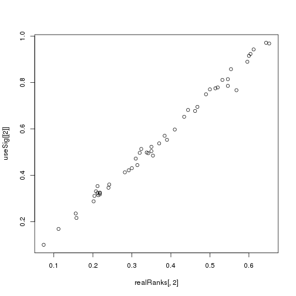

```r
plot(realRanks[, 2], useSig[[2]])
```

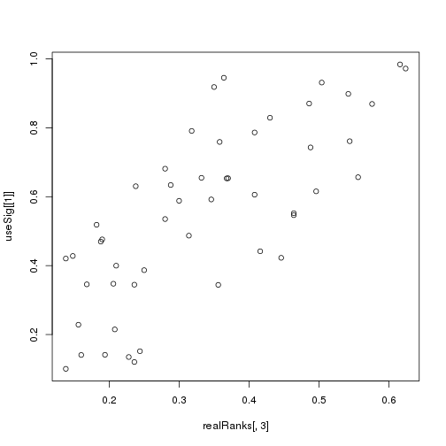

```r
plot(realRanks[, 3], useSig[[1]])
```

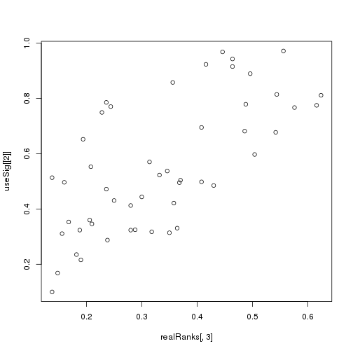

```r
plot(realRanks[, 3], useSig[[2]])
```

OK, this seems to be working still.

Now, lets try this on some fake data.

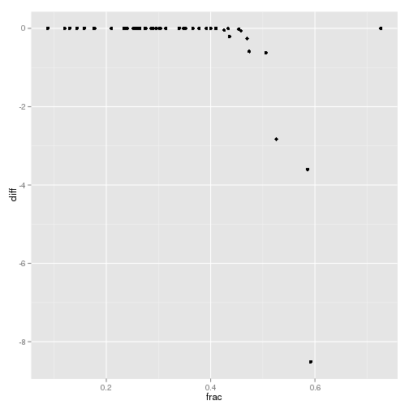

```r
testSize <- gseaSizeRange(c(500, 500), 50)
useStatistics <- runif(10000, -6, 6)
useSig <- list(s1 = runif(50, 0.1, 1), s2 = runif(50, 0.1, 1))
testStats <- gseaProportionVary(testSize, useSig, useStatistics)

outP <- lapply(testStats, function(inStat) {
    tmpP <- lapply(seq(1, ncol(inStat$stats)), function(useColumn) {
        geneSetTest(inStat$index, inStat$stats[, useColumn], "down", ranks.only = FALSE)
    })
    tmpP <- do.call(cbind, tmpP)
    colnames(tmpP) <- colnames(inStat$stats)
    return(tmpP)
})

outP2 <- do.call(rbind, outP)
outP2 <- -1 * log(outP2)

tmpP <- data.frame(set = apply(outP2[, c("s1", "s2")], 1, min), list = outP2[,
    "comb"])
tmpP$diff <- tmpP$set - tmpP$list

realRanks <- lapply(testStats, function(inStat) {

    apply(inStat$stats, 2, function(inCol) {
        outRank <- rank(inCol)[inStat$index]
        sum(outRank < useCut)/length(inStat$index)
    })

})

realRanks <- do.call(rbind, realRanks)

tmpP$frac <- realRanks[, 3]
ggplot(tmpP, aes(x = frac, y = diff)) + geom_point()
```

So, none of this has really worked, at least not in the way that was hoped.

### GSEA using p-values instead of t-statistics

For our hypothetical comparison, we need to think of how one would combine two studies. In this case, one might combine two studies by combining the p-values. Therefore, we will use ranked p-values as our metric in the `geneSetTest`.

For this to work with `geneSetTest`, we need to make the range 0, 0.5, 1 conform to -1, 0, 1, because `geneSetTest` works nicer with signed values. We will use a linear regression to transform the p-values to a signed range.

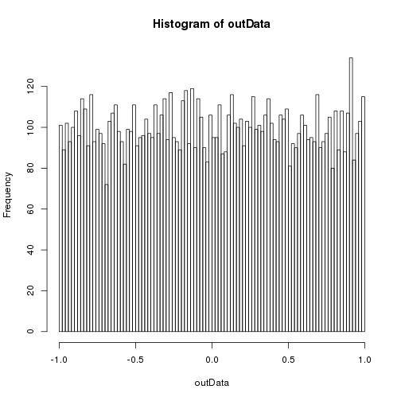

```r
regData <- data.frame(y = c(-1, 0, 1), x = c(0, 0.5, 1))
regModel <- lm(y ~ x, regData)

testData <- runif(10000, 0, 1)
outData <- regModel$coefficients[1] + regModel$coefficients[2] * testData
hist(outData, 100)
```

So our transformation works. Lets make sure it will work like the t-statistic.

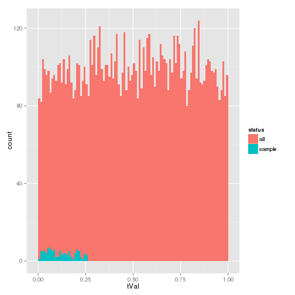

```r
nGene <- 10000
indepTValues <- sort(runif(nGene, 0, 1))
names(indepTValues) <- as.character(seq(1, nGene))

gseaMap <- list(t1 = sample(seq(1, nGene/4), 100))

tmpDat <- data.frame(tVal = indepTValues, status = "all", stringsAsFactors = F)
tmpDat$status[gseaMap[["t1"]]] <- "sample"
ggplot(tmpDat, aes(x = tVal, fill = status)) + geom_histogram(binwidt = 0.01,
    position = "identity")
```

```r
geneSetTest(gseaMap$t1, p2signed(regModel, indepTValues), alternative = "down",
    ranks.only = FALSE)
```

```
## [1] 1e-04
```

```r
gseaMap80 <- list(t1 = c(sample(seq(1, nGene/2), 80), sample(seq((nGene/2) +
    1, nGene), 20)))

geneSetTest(gseaMap80$t1, p2signed(regModel, indepTValues), alternative = "down",
    ranks.only = FALSE)
```

```
## [1] 1e-04
```

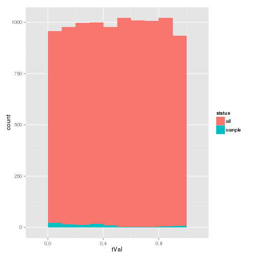

```r
tmpDat <- data.frame(tVal = indepTValues, status = "all", stringsAsFactors = F)
tmpDat$status[gseaMap80[["t1"]]] <- "sample"
ggplot(tmpDat, aes(x = tVal, fill = status)) + geom_histogram(binwidt = 0.1,
    position = "identity")
```

```r
gseaMap50 <- list(t1 = c(sample(seq(1, nGene/2), 50), sample(seq((nGene/2) +
    1, nGene), 50)))

geneSetTest(gseaMap50$t1, p2signed(regModel, indepTValues), alternative = "down",
    ranks.only = FALSE)
```

```
## [1] 0.2328
```

Now, lets maintain proportions between samples as we did before, but for the **list** method, combine the p-values using Fisher's method.

```r
`?`(gseaProportionFisher)
```

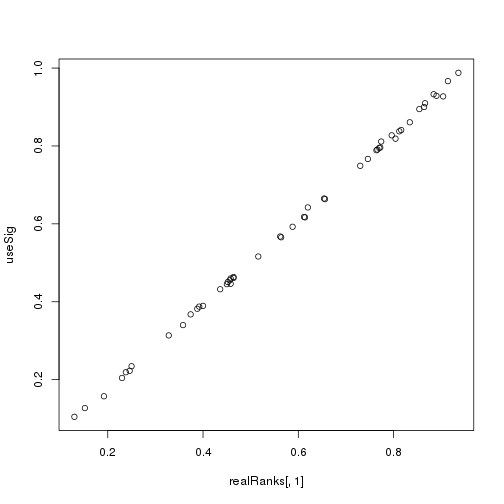

```r
testSize <- gseaSizeRange(c(500, 500), 50)
useStatistics <- runif(10000, 0, 1)
useSig <- runif(50, 0.1, 1)
testStats <- gseaProportionFisher(testSize, useSig, useStatistics)

fullIndex <- seq(1, length(useStatistics))
useCut <- 5000

realRanks <- lapply(testStats, function(inStat) {

    apply(inStat$stats, 2, function(inCol) {
        outRank <- rank(inCol)[inStat$index]
        sum(outRank < useCut)/length(inStat$index)
    })

})

realRanks <- do.call(rbind, realRanks)
plot(realRanks[, 1], useSig)
```

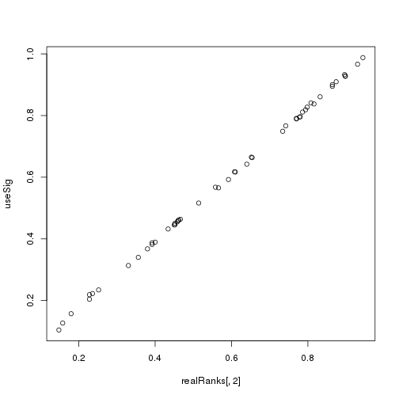

```r
plot(realRanks[, 2], useSig)
```

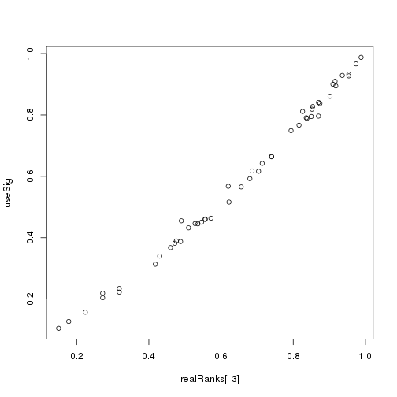

```r
plot(realRanks[, 3], useSig)
```

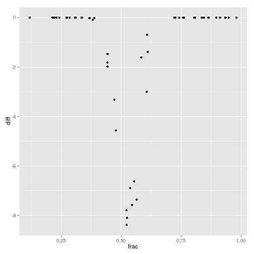

```r
testSize <- gseaSizeRange(c(500, 500), 50)
useStatistics <- runif(10000, 0, 1)
useSig <- runif(50, 0.1, 1)
testStats <- gseaProportionFisher(testSize, useSig, useStatistics)

outP <- lapply(testStats, function(inStat) {
    tmpP <- lapply(seq(1, ncol(inStat$stats)), function(useColumn) {
        geneSetTest(inStat$index, p2signed(regModel, inStat$stats[, useColumn]),
            "down", ranks.only = FALSE)
    })
    tmpP <- do.call(cbind, tmpP)
    colnames(tmpP) <- colnames(inStat$stats)
    return(tmpP)
})

outP2 <- do.call(rbind, outP)
outP2 <- -1 * log(outP2)

tmpP <- data.frame(set = apply(outP2[, c("s1", "s2")], 1, min), list = outP2[,
    "comb"])
tmpP$diff <- tmpP$set - tmpP$list
tmpP$frac <- useSig
ggplot(tmpP, aes(x = frac, y = diff)) + geom_point()
```

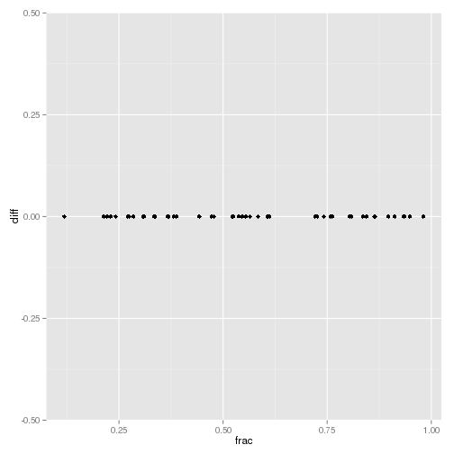

```r
# try also using ranks only
outPRank <- lapply(testStats, function(inStat) {
    tmpP <- lapply(seq(1, ncol(inStat$stats)), function(useColumn) {
        geneSetTest(inStat$index, inStat$stats, ranks.only = TRUE)
    })
    tmpP <- do.call(cbind, tmpP)
    colnames(tmpP) <- colnames(inStat$stats)
    return(tmpP)
})

outP2Rank <- do.call(rbind, outPRank)
outP2Rank <- -1 * log(outP2Rank)

tmpP <- data.frame(set = apply(outP2Rank[, c("s1", "s2")], 1, min), list = outP2Rank[,
    "comb"])
tmpP$diff <- tmpP$set - tmpP$list
tmpP$frac <- useSig
ggplot(tmpP, aes(x = frac, y = diff)) + geom_point()
```